# Risk Factor Analysis

## Outcome Variable

**Outcome Variable:** y_rate_haz

## Predictor Variables

**Intervention Variable:** nchldlt5

**Adjustment Set:**

- arm
- W_mage
- meducyrs
- feducyrs
- hhwealth_quart
- hfoodsec
- W_mhtcm
- W_nrooms
- W_parity
- impfloor
- impsan
- safeh20
- delta_W_mage
- delta_meducyrs
- delta_feducyrs
- delta_hhwealth_quart
- delta_hfoodsec
- delta_W_mhtcm
- delta_W_nrooms
- delta_W_parity
- delta_impfloor
- delta_impsan
- delta_safeh20

## Stratifying Variables

The analysis was stratified on these variable(s):

- agecat
- studyid
- country

## Data Summary

| agecat | studyid | country | nchldlt5 | n_cell | n |
| --- | --- | --- | --- | --- | --- |
| 0-3 months | ki1017093b-PROVIDE | BANGLADESH | 1 | 467 | 634 |
| 0-3 months | ki1017093b-PROVIDE | BANGLADESH | 2 | 158 | 634 |
| 0-3 months | ki1017093b-PROVIDE | BANGLADESH | 3+ | 9 | 634 |
| 0-3 months | ki1017093c-NIH-Crypto | BANGLADESH | 1 | 511 | 720 |
| 0-3 months | ki1017093c-NIH-Crypto | BANGLADESH | 2 | 203 | 720 |
| 0-3 months | ki1017093c-NIH-Crypto | BANGLADESH | 3+ | 6 | 720 |
| 0-3 months | kiGH5241-JiVitA-3 | BANGLADESH | 1 | 12472 | 20027 |
| 0-3 months | kiGH5241-JiVitA-3 | BANGLADESH | 2 | 7095 | 20027 |
| 0-3 months | kiGH5241-JiVitA-3 | BANGLADESH | 3+ | 460 | 20027 |
| 0-3 months | ki1000108-IRC | INDIA | 1 | 82 | 377 |
| 0-3 months | ki1000108-IRC | INDIA | 2 | 109 | 377 |
| 0-3 months | ki1000108-IRC | INDIA | 3+ | 186 | 377 |
| 3-6 months | ki1017093b-PROVIDE | BANGLADESH | 1 | 421 | 574 |
| 3-6 months | ki1017093b-PROVIDE | BANGLADESH | 2 | 145 | 574 |
| 3-6 months | ki1017093b-PROVIDE | BANGLADESH | 3+ | 8 | 574 |
| 3-6 months | ki1017093c-NIH-Crypto | BANGLADESH | 1 | 492 | 695 |
| 3-6 months | ki1017093c-NIH-Crypto | BANGLADESH | 2 | 198 | 695 |
| 3-6 months | ki1017093c-NIH-Crypto | BANGLADESH | 3+ | 5 | 695 |
| 3-6 months | kiGH5241-JiVitA-3 | BANGLADESH | 1 | 8102 | 12571 |
| 3-6 months | kiGH5241-JiVitA-3 | BANGLADESH | 2 | 4211 | 12571 |
| 3-6 months | kiGH5241-JiVitA-3 | BANGLADESH | 3+ | 258 | 12571 |
| 3-6 months | ki1000108-IRC | INDIA | 1 | 87 | 397 |
| 3-6 months | ki1000108-IRC | INDIA | 2 | 114 | 397 |
| 3-6 months | ki1000108-IRC | INDIA | 3+ | 196 | 397 |
| 3-6 months | ki1066203-TanzaniaChild2 | TANZANIA, UNITED REPUBLIC OF | 1 | 1145 | 1655 |
| 3-6 months | ki1066203-TanzaniaChild2 | TANZANIA, UNITED REPUBLIC OF | 2 | 461 | 1655 |
| 3-6 months | ki1066203-TanzaniaChild2 | TANZANIA, UNITED REPUBLIC OF | 3+ | 49 | 1655 |
| 6-12 months | ki1017093b-PROVIDE | BANGLADESH | 1 | 399 | 545 |
| 6-12 months | ki1017093b-PROVIDE | BANGLADESH | 2 | 138 | 545 |
| 6-12 months | ki1017093b-PROVIDE | BANGLADESH | 3+ | 8 | 545 |
| 6-12 months | ki1017093c-NIH-Crypto | BANGLADESH | 1 | 474 | 676 |
| 6-12 months | ki1017093c-NIH-Crypto | BANGLADESH | 2 | 198 | 676 |
| 6-12 months | ki1017093c-NIH-Crypto | BANGLADESH | 3+ | 4 | 676 |
| 6-12 months | kiGH5241-JiVitA-3 | BANGLADESH | 1 | 6298 | 9831 |
| 6-12 months | kiGH5241-JiVitA-3 | BANGLADESH | 2 | 3328 | 9831 |
| 6-12 months | kiGH5241-JiVitA-3 | BANGLADESH | 3+ | 205 | 9831 |
| 6-12 months | ki1000108-IRC | INDIA | 1 | 88 | 400 |
| 6-12 months | ki1000108-IRC | INDIA | 2 | 116 | 400 |
| 6-12 months | ki1000108-IRC | INDIA | 3+ | 196 | 400 |
| 6-12 months | ki1148112-LCNI-5 | MALAWI | 1 | 205 | 428 |
| 6-12 months | ki1148112-LCNI-5 | MALAWI | 2 | 195 | 428 |
| 6-12 months | ki1148112-LCNI-5 | MALAWI | 3+ | 28 | 428 |
| 6-12 months | ki1066203-TanzaniaChild2 | TANZANIA, UNITED REPUBLIC OF | 1 | 769 | 1077 |
| 6-12 months | ki1066203-TanzaniaChild2 | TANZANIA, UNITED REPUBLIC OF | 2 | 279 | 1077 |
| 6-12 months | ki1066203-TanzaniaChild2 | TANZANIA, UNITED REPUBLIC OF | 3+ | 29 | 1077 |
| 12-24 months | ki1017093b-PROVIDE | BANGLADESH | 1 | 331 | 458 |
| 12-24 months | ki1017093b-PROVIDE | BANGLADESH | 2 | 121 | 458 |
| 12-24 months | ki1017093b-PROVIDE | BANGLADESH | 3+ | 6 | 458 |
| 12-24 months | ki1017093c-NIH-Crypto | BANGLADESH | 1 | 341 | 495 |
| 12-24 months | ki1017093c-NIH-Crypto | BANGLADESH | 2 | 151 | 495 |
| 12-24 months | ki1017093c-NIH-Crypto | BANGLADESH | 3+ | 3 | 495 |
| 12-24 months | kiGH5241-JiVitA-3 | BANGLADESH | 1 | 2907 | 4647 |
| 12-24 months | kiGH5241-JiVitA-3 | BANGLADESH | 2 | 1627 | 4647 |
| 12-24 months | kiGH5241-JiVitA-3 | BANGLADESH | 3+ | 113 | 4647 |
| 12-24 months | ki1000108-IRC | INDIA | 1 | 86 | 396 |
| 12-24 months | ki1000108-IRC | INDIA | 2 | 116 | 396 |
| 12-24 months | ki1000108-IRC | INDIA | 3+ | 194 | 396 |
| 12-24 months | ki1148112-LCNI-5 | MALAWI | 1 | 152 | 306 |
| 12-24 months | ki1148112-LCNI-5 | MALAWI | 2 | 135 | 306 |
| 12-24 months | ki1148112-LCNI-5 | MALAWI | 3+ | 19 | 306 |
| 12-24 months | ki1066203-TanzaniaChild2 | TANZANIA, UNITED REPUBLIC OF | 1 | 1 | 2 |
| 12-24 months | ki1066203-TanzaniaChild2 | TANZANIA, UNITED REPUBLIC OF | 2 | 1 | 2 |

The following strata were considered:

- agecat: 0-3 months, studyid: ki1000108-IRC, country: INDIA
- agecat: 0-3 months, studyid: ki1017093b-PROVIDE, country: BANGLADESH
- agecat: 0-3 months, studyid: ki1017093c-NIH-Crypto, country: BANGLADESH
- agecat: 0-3 months, studyid: kiGH5241-JiVitA-3, country: BANGLADESH
- agecat: 12-24 months, studyid: ki1000108-IRC, country: INDIA
- agecat: 12-24 months, studyid: ki1017093b-PROVIDE, country: BANGLADESH
- agecat: 12-24 months, studyid: ki1017093c-NIH-Crypto, country: BANGLADESH
- agecat: 12-24 months, studyid: ki1066203-TanzaniaChild2, country: TANZANIA, UNITED REPUBLIC OF
- agecat: 12-24 months, studyid: ki1148112-LCNI-5, country: MALAWI
- agecat: 12-24 months, studyid: kiGH5241-JiVitA-3, country: BANGLADESH
- agecat: 3-6 months, studyid: ki1000108-IRC, country: INDIA
- agecat: 3-6 months, studyid: ki1017093b-PROVIDE, country: BANGLADESH
- agecat: 3-6 months, studyid: ki1017093c-NIH-Crypto, country: BANGLADESH
- agecat: 3-6 months, studyid: ki1066203-TanzaniaChild2, country: TANZANIA, UNITED REPUBLIC OF
- agecat: 3-6 months, studyid: kiGH5241-JiVitA-3, country: BANGLADESH
- agecat: 6-12 months, studyid: ki1000108-IRC, country: INDIA
- agecat: 6-12 months, studyid: ki1017093b-PROVIDE, country: BANGLADESH
- agecat: 6-12 months, studyid: ki1017093c-NIH-Crypto, country: BANGLADESH
- agecat: 6-12 months, studyid: ki1066203-TanzaniaChild2, country: TANZANIA, UNITED REPUBLIC OF
- agecat: 6-12 months, studyid: ki1148112-LCNI-5, country: MALAWI
- agecat: 6-12 months, studyid: kiGH5241-JiVitA-3, country: BANGLADESH

### Dropped Strata

Some strata were dropped due to rare outcomes:

- agecat: 6-12 months, studyid: ki1017093c-NIH-Crypto, country: BANGLADESH
- agecat: 12-24 months, studyid: ki1017093c-NIH-Crypto, country: BANGLADESH
- agecat: 12-24 months, studyid: ki1066203-TanzaniaChild2, country: TANZANIA, UNITED REPUBLIC OF

## Methods Detail

We’re interested in the causal parameters $E[Y_a]$ for all values of $a \in \mathcal{A}$. These parameters represent the mean outcome if, possibly contrary to fact, we intervened to set all units to have $A=a$. Under the randomization and positivity assumptions, these are identified by the statistical parameters $\psi_a=E_W[E_{Y|A,W}(Y|A=a,W)]$. In addition, we’re interested in the mean of $Y$, $E[Y]$ under no intervention (the observed mean). We will estimate these parameters by using SuperLearner to fit the relevant likelihood factors – $E_{Y|A,W}(Y|A=a,W)$ and $p(A=a|W)$, and then updating our likelihood fit using a joint TMLE.

For unadjusted analyses ($W=\{\}$), initial likelihoods were estimated using Lrnr_glm to estimate the simple $E(Y|A)$ and Lrnr_mean to estimate $p(A)$. For adjusted analyses, a small library containing Lrnr_glmnet, Lrnr_xgboost, and Lrnr_mean was used.

Having estimated these parameters, we will then use the delta method to estimate relative risks and attributable risks relative to a prespecified baseline level of $A$.

# Results Detail

## Results Plots

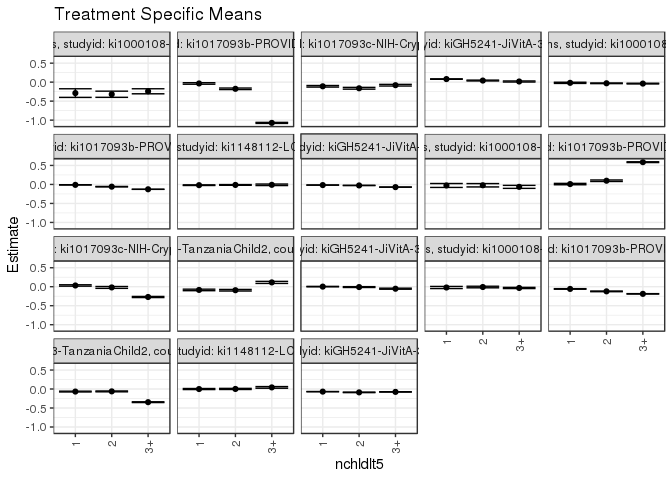

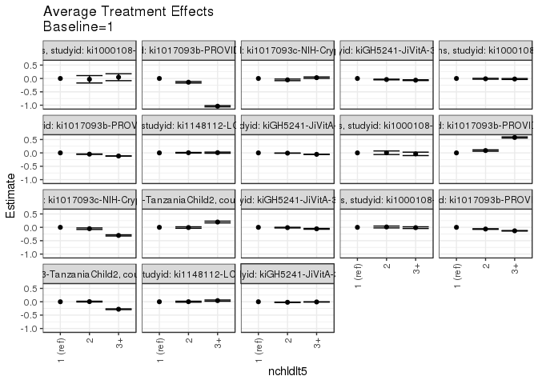

## Results Table

### Parameter: TSM

| agecat | studyid | country | intervention_level | baseline_level | estimate | ci_lower | ci_upper |
| --- | --- | --- | --- | --- | --- | --- | --- |
| 0-3 months | ki1000108-IRC | INDIA | 1 | NA | -0.2882680 | -0.4016703 | -0.1748656 |
| 0-3 months | ki1000108-IRC | INDIA | 2 | NA | -0.3189885 | -0.3997661 | -0.2382109 |
| 0-3 months | ki1000108-IRC | INDIA | 3+ | NA | -0.2404684 | -0.3070378 | -0.1738990 |
| 0-3 months | ki1017093b-PROVIDE | BANGLADESH | 1 | NA | -0.0350127 | -0.0545264 | -0.0154989 |
| 0-3 months | ki1017093b-PROVIDE | BANGLADESH | 2 | NA | -0.1756980 | -0.1957877 | -0.1556083 |
| 0-3 months | ki1017093b-PROVIDE | BANGLADESH | 3+ | NA | -1.0727694 | -1.0862638 | -1.0592750 |
| 0-3 months | ki1017093c-NIH-Crypto | BANGLADESH | 1 | NA | -0.1096504 | -0.1297437 | -0.0895571 |
| 0-3 months | ki1017093c-NIH-Crypto | BANGLADESH | 2 | NA | -0.1618556 | -0.1851229 | -0.1385882 |
| 0-3 months | ki1017093c-NIH-Crypto | BANGLADESH | 3+ | NA | -0.0802192 | -0.1019755 | -0.0584628 |
| 0-3 months | kiGH5241-JiVitA-3 | BANGLADESH | 1 | NA | 0.0808043 | 0.0746813 | 0.0869272 |
| 0-3 months | kiGH5241-JiVitA-3 | BANGLADESH | 2 | NA | 0.0416749 | 0.0303656 | 0.0529842 |
| 0-3 months | kiGH5241-JiVitA-3 | BANGLADESH | 3+ | NA | 0.0167522 | 0.0031076 | 0.0303969 |
| 3-6 months | ki1000108-IRC | INDIA | 1 | NA | -0.0275627 | -0.0788821 | 0.0237568 |
| 3-6 months | ki1000108-IRC | INDIA | 2 | NA | -0.0220814 | -0.0657479 | 0.0215852 |
| 3-6 months | ki1000108-IRC | INDIA | 3+ | NA | -0.0637521 | -0.1032288 | -0.0242753 |
| 3-6 months | ki1017093b-PROVIDE | BANGLADESH | 1 | NA | 0.0093077 | -0.0082311 | 0.0268464 |
| 3-6 months | ki1017093b-PROVIDE | BANGLADESH | 2 | NA | 0.0974179 | 0.0779345 | 0.1169013 |
| 3-6 months | ki1017093b-PROVIDE | BANGLADESH | 3+ | NA | 0.5862909 | 0.5765055 | 0.5960763 |
| 3-6 months | ki1017093c-NIH-Crypto | BANGLADESH | 1 | NA | 0.0325579 | 0.0143658 | 0.0507500 |
| 3-6 months | ki1017093c-NIH-Crypto | BANGLADESH | 2 | NA | -0.0187590 | -0.0429817 | 0.0054638 |
| 3-6 months | ki1017093c-NIH-Crypto | BANGLADESH | 3+ | NA | -0.2705709 | -0.2851579 | -0.2559838 |
| 3-6 months | ki1066203-TanzaniaChild2 | TANZANIA, UNITED REPUBLIC OF | 1 | NA | -0.0843613 | -0.1038874 | -0.0648351 |
| 3-6 months | ki1066203-TanzaniaChild2 | TANZANIA, UNITED REPUBLIC OF | 2 | NA | -0.0920679 | -0.1125088 | -0.0716271 |
| 3-6 months | ki1066203-TanzaniaChild2 | TANZANIA, UNITED REPUBLIC OF | 3+ | NA | 0.1136148 | 0.0867931 | 0.1404365 |
| 3-6 months | kiGH5241-JiVitA-3 | BANGLADESH | 1 | NA | 0.0026111 | -0.0035936 | 0.0088158 |
| 3-6 months | kiGH5241-JiVitA-3 | BANGLADESH | 2 | NA | -0.0089298 | -0.0198927 | 0.0020330 |
| 3-6 months | kiGH5241-JiVitA-3 | BANGLADESH | 3+ | NA | -0.0528563 | -0.0666298 | -0.0390827 |
| 6-12 months | ki1000108-IRC | INDIA | 1 | NA | -0.0208320 | -0.0490997 | 0.0074356 |
| 6-12 months | ki1000108-IRC | INDIA | 2 | NA | -0.0077730 | -0.0283064 | 0.0127603 |
| 6-12 months | ki1000108-IRC | INDIA | 3+ | NA | -0.0329693 | -0.0481725 | -0.0177661 |
| 6-12 months | ki1017093b-PROVIDE | BANGLADESH | 1 | NA | -0.0582619 | -0.0658377 | -0.0506861 |
| 6-12 months | ki1017093b-PROVIDE | BANGLADESH | 2 | NA | -0.1217656 | -0.1300289 | -0.1135022 |
| 6-12 months | ki1017093b-PROVIDE | BANGLADESH | 3+ | NA | -0.1880491 | -0.1929154 | -0.1831829 |
| 6-12 months | ki1066203-TanzaniaChild2 | TANZANIA, UNITED REPUBLIC OF | 1 | NA | -0.0673419 | -0.0772865 | -0.0573972 |
| 6-12 months | ki1066203-TanzaniaChild2 | TANZANIA, UNITED REPUBLIC OF | 2 | NA | -0.0623492 | -0.0735849 | -0.0511135 |
| 6-12 months | ki1066203-TanzaniaChild2 | TANZANIA, UNITED REPUBLIC OF | 3+ | NA | -0.3466530 | -0.3574641 | -0.3358420 |
| 6-12 months | ki1148112-LCNI-5 | MALAWI | 1 | NA | -0.0007436 | -0.0149472 | 0.0134600 |
| 6-12 months | ki1148112-LCNI-5 | MALAWI | 2 | NA | 0.0015174 | -0.0130190 | 0.0160538 |
| 6-12 months | ki1148112-LCNI-5 | MALAWI | 3+ | NA | 0.0421536 | 0.0211207 | 0.0631864 |
| 6-12 months | kiGH5241-JiVitA-3 | BANGLADESH | 1 | NA | -0.0686188 | -0.0721610 | -0.0650767 |
| 6-12 months | kiGH5241-JiVitA-3 | BANGLADESH | 2 | NA | -0.0884533 | -0.0944867 | -0.0824199 |
| 6-12 months | kiGH5241-JiVitA-3 | BANGLADESH | 3+ | NA | -0.0759174 | -0.0809314 | -0.0709034 |
| 12-24 months | ki1000108-IRC | INDIA | 1 | NA | -0.0184376 | -0.0336487 | -0.0032265 |
| 12-24 months | ki1000108-IRC | INDIA | 2 | NA | -0.0301460 | -0.0386469 | -0.0216450 |
| 12-24 months | ki1000108-IRC | INDIA | 3+ | NA | -0.0381198 | -0.0473244 | -0.0289153 |
| 12-24 months | ki1017093b-PROVIDE | BANGLADESH | 1 | NA | -0.0114786 | -0.0156361 | -0.0073210 |
| 12-24 months | ki1017093b-PROVIDE | BANGLADESH | 2 | NA | -0.0589264 | -0.0640869 | -0.0537658 |
| 12-24 months | ki1017093b-PROVIDE | BANGLADESH | 3+ | NA | -0.1276514 | -0.1294502 | -0.1258526 |
| 12-24 months | ki1148112-LCNI-5 | MALAWI | 1 | NA | -0.0193857 | -0.0277090 | -0.0110624 |
| 12-24 months | ki1148112-LCNI-5 | MALAWI | 2 | NA | -0.0133356 | -0.0221447 | -0.0045266 |
| 12-24 months | ki1148112-LCNI-5 | MALAWI | 3+ | NA | -0.0102907 | -0.0303021 | 0.0097206 |
| 12-24 months | kiGH5241-JiVitA-3 | BANGLADESH | 1 | NA | -0.0173680 | -0.0196569 | -0.0150791 |
| 12-24 months | kiGH5241-JiVitA-3 | BANGLADESH | 2 | NA | -0.0266411 | -0.0296450 | -0.0236372 |
| 12-24 months | kiGH5241-JiVitA-3 | BANGLADESH | 3+ | NA | -0.0709098 | -0.0729565 | -0.0688631 |

### Parameter: E(Y)

| agecat | studyid | country | intervention_level | baseline_level | estimate | ci_lower | ci_upper |
| --- | --- | --- | --- | --- | --- | --- | --- |
| 0-3 months | ki1000108-IRC | INDIA | NA | NA | -0.2594964 | -0.3154509 | -0.2035418 |
| 0-3 months | ki1017093b-PROVIDE | BANGLADESH | NA | NA | -0.0413143 | -0.0594662 | -0.0231624 |
| 0-3 months | ki1017093c-NIH-Crypto | BANGLADESH | NA | NA | -0.1220821 | -0.1402761 | -0.1038881 |
| 0-3 months | kiGH5241-JiVitA-3 | BANGLADESH | NA | NA | 0.0705498 | 0.0655945 | 0.0755050 |
| 3-6 months | ki1000108-IRC | INDIA | NA | NA | -0.0518918 | -0.0819849 | -0.0217987 |
| 3-6 months | ki1017093b-PROVIDE | BANGLADESH | NA | NA | -0.0272428 | -0.0436954 | -0.0107902 |
| 3-6 months | ki1017093c-NIH-Crypto | BANGLADESH | NA | NA | 0.0267740 | 0.0099602 | 0.0435879 |
| 3-6 months | ki1066203-TanzaniaChild2 | TANZANIA, UNITED REPUBLIC OF | NA | NA | -0.0855875 | -0.1022050 | -0.0689699 |
| 3-6 months | kiGH5241-JiVitA-3 | BANGLADESH | NA | NA | -0.0034268 | -0.0082920 | 0.0014385 |
| 6-12 months | ki1000108-IRC | INDIA | NA | NA | -0.0260151 | -0.0389122 | -0.0131180 |
| 6-12 months | ki1017093b-PROVIDE | BANGLADESH | NA | NA | -0.0626151 | -0.0695574 | -0.0556729 |
| 6-12 months | ki1066203-TanzaniaChild2 | TANZANIA, UNITED REPUBLIC OF | NA | NA | -0.0595549 | -0.0687696 | -0.0503402 |
| 6-12 months | ki1148112-LCNI-5 | MALAWI | NA | NA | -0.0060302 | -0.0170093 | 0.0049488 |
| 6-12 months | kiGH5241-JiVitA-3 | BANGLADESH | NA | NA | -0.0748335 | -0.0776775 | -0.0719894 |
| 12-24 months | ki1000108-IRC | INDIA | NA | NA | -0.0317687 | -0.0388357 | -0.0247017 |
| 12-24 months | ki1017093b-PROVIDE | BANGLADESH | NA | NA | -0.0081718 | -0.0120131 | -0.0043304 |
| 12-24 months | ki1148112-LCNI-5 | MALAWI | NA | NA | -0.0161503 | -0.0219777 | -0.0103229 |
| 12-24 months | kiGH5241-JiVitA-3 | BANGLADESH | NA | NA | -0.0187696 | -0.0206191 | -0.0169201 |

### Parameter: ATE

| agecat | studyid | country | intervention_level | baseline_level | estimate | ci_lower | ci_upper |
| --- | --- | --- | --- | --- | --- | --- | --- |
| 0-3 months | ki1000108-IRC | INDIA | 1 | 1 | 0.0000000 | 0.0000000 | 0.0000000 |
| 0-3 months | ki1000108-IRC | INDIA | 2 | 1 | -0.0307205 | -0.1687565 | 0.1073154 |
| 0-3 months | ki1000108-IRC | INDIA | 3+ | 1 | 0.0477996 | -0.0817127 | 0.1773119 |
| 0-3 months | ki1017093b-PROVIDE | BANGLADESH | 1 | 1 | 0.0000000 | 0.0000000 | 0.0000000 |
| 0-3 months | ki1017093b-PROVIDE | BANGLADESH | 2 | 1 | -0.1406853 | -0.1687807 | -0.1125900 |
| 0-3 months | ki1017093b-PROVIDE | BANGLADESH | 3+ | 1 | -1.0377567 | -1.0617274 | -1.0137861 |
| 0-3 months | ki1017093c-NIH-Crypto | BANGLADESH | 1 | 1 | 0.0000000 | 0.0000000 | 0.0000000 |
| 0-3 months | ki1017093c-NIH-Crypto | BANGLADESH | 2 | 1 | -0.0522052 | -0.0816998 | -0.0227105 |
| 0-3 months | ki1017093c-NIH-Crypto | BANGLADESH | 3+ | 1 | 0.0294312 | 0.0010061 | 0.0578564 |
| 0-3 months | kiGH5241-JiVitA-3 | BANGLADESH | 1 | 1 | 0.0000000 | 0.0000000 | 0.0000000 |
| 0-3 months | kiGH5241-JiVitA-3 | BANGLADESH | 2 | 1 | -0.0391293 | -0.0516562 | -0.0266025 |
| 0-3 months | kiGH5241-JiVitA-3 | BANGLADESH | 3+ | 1 | -0.0640520 | -0.0787030 | -0.0494010 |
| 3-6 months | ki1000108-IRC | INDIA | 1 | 1 | 0.0000000 | 0.0000000 | 0.0000000 |
| 3-6 months | ki1000108-IRC | INDIA | 2 | 1 | 0.0054813 | -0.0613550 | 0.0723176 |
| 3-6 months | ki1000108-IRC | INDIA | 3+ | 1 | -0.0361894 | -0.1001511 | 0.0277723 |
| 3-6 months | ki1017093b-PROVIDE | BANGLADESH | 1 | 1 | 0.0000000 | 0.0000000 | 0.0000000 |
| 3-6 months | ki1017093b-PROVIDE | BANGLADESH | 2 | 1 | 0.0881103 | 0.0616916 | 0.1145289 |
| 3-6 months | ki1017093b-PROVIDE | BANGLADESH | 3+ | 1 | 0.5769833 | 0.5557839 | 0.5981827 |
| 3-6 months | ki1017093c-NIH-Crypto | BANGLADESH | 1 | 1 | 0.0000000 | 0.0000000 | 0.0000000 |
| 3-6 months | ki1017093c-NIH-Crypto | BANGLADESH | 2 | 1 | -0.0513169 | -0.0803611 | -0.0222727 |
| 3-6 months | ki1017093c-NIH-Crypto | BANGLADESH | 3+ | 1 | -0.3031288 | -0.3256520 | -0.2806056 |
| 3-6 months | ki1066203-TanzaniaChild2 | TANZANIA, UNITED REPUBLIC OF | 1 | 1 | 0.0000000 | 0.0000000 | 0.0000000 |
| 3-6 months | ki1066203-TanzaniaChild2 | TANZANIA, UNITED REPUBLIC OF | 2 | 1 | -0.0077067 | -0.0353138 | 0.0199005 |
| 3-6 months | ki1066203-TanzaniaChild2 | TANZANIA, UNITED REPUBLIC OF | 3+ | 1 | 0.1979761 | 0.1652914 | 0.2306608 |
| 3-6 months | kiGH5241-JiVitA-3 | BANGLADESH | 1 | 1 | 0.0000000 | 0.0000000 | 0.0000000 |
| 3-6 months | kiGH5241-JiVitA-3 | BANGLADESH | 2 | 1 | -0.0115409 | -0.0238203 | 0.0007384 |
| 3-6 months | kiGH5241-JiVitA-3 | BANGLADESH | 3+ | 1 | -0.0554674 | -0.0710489 | -0.0398858 |
| 6-12 months | ki1000108-IRC | INDIA | 1 | 1 | 0.0000000 | 0.0000000 | 0.0000000 |
| 6-12 months | ki1000108-IRC | INDIA | 2 | 1 | 0.0130590 | -0.0215517 | 0.0476696 |
| 6-12 months | ki1000108-IRC | INDIA | 3+ | 1 | -0.0121373 | -0.0436818 | 0.0194072 |
| 6-12 months | ki1017093b-PROVIDE | BANGLADESH | 1 | 1 | 0.0000000 | 0.0000000 | 0.0000000 |
| 6-12 months | ki1017093b-PROVIDE | BANGLADESH | 2 | 1 | -0.0635036 | -0.0747584 | -0.0522488 |
| 6-12 months | ki1017093b-PROVIDE | BANGLADESH | 3+ | 1 | -0.1297872 | -0.1389657 | -0.1206087 |
| 6-12 months | ki1066203-TanzaniaChild2 | TANZANIA, UNITED REPUBLIC OF | 1 | 1 | 0.0000000 | 0.0000000 | 0.0000000 |
| 6-12 months | ki1066203-TanzaniaChild2 | TANZANIA, UNITED REPUBLIC OF | 2 | 1 | 0.0049926 | -0.0095083 | 0.0194936 |
| 6-12 months | ki1066203-TanzaniaChild2 | TANZANIA, UNITED REPUBLIC OF | 3+ | 1 | -0.2793112 | -0.2935998 | -0.2650225 |
| 6-12 months | ki1148112-LCNI-5 | MALAWI | 1 | 1 | 0.0000000 | 0.0000000 | 0.0000000 |
| 6-12 months | ki1148112-LCNI-5 | MALAWI | 2 | 1 | 0.0022610 | -0.0165605 | 0.0210824 |
| 6-12 months | ki1148112-LCNI-5 | MALAWI | 3+ | 1 | 0.0428971 | 0.0185982 | 0.0671960 |
| 6-12 months | kiGH5241-JiVitA-3 | BANGLADESH | 1 | 1 | 0.0000000 | 0.0000000 | 0.0000000 |
| 6-12 months | kiGH5241-JiVitA-3 | BANGLADESH | 2 | 1 | -0.0198345 | -0.0265609 | -0.0131080 |
| 6-12 months | kiGH5241-JiVitA-3 | BANGLADESH | 3+ | 1 | -0.0072986 | -0.0134546 | -0.0011425 |
| 12-24 months | ki1000108-IRC | INDIA | 1 | 1 | 0.0000000 | 0.0000000 | 0.0000000 |
| 12-24 months | ki1000108-IRC | INDIA | 2 | 1 | -0.0117084 | -0.0289594 | 0.0055427 |
| 12-24 months | ki1000108-IRC | INDIA | 3+ | 1 | -0.0196822 | -0.0372227 | -0.0021417 |
| 12-24 months | ki1017093b-PROVIDE | BANGLADESH | 1 | 1 | 0.0000000 | 0.0000000 | 0.0000000 |
| 12-24 months | ki1017093b-PROVIDE | BANGLADESH | 2 | 1 | -0.0474478 | -0.0544296 | -0.0404659 |
| 12-24 months | ki1017093b-PROVIDE | BANGLADESH | 3+ | 1 | -0.1161728 | -0.1208368 | -0.1115089 |
| 12-24 months | ki1148112-LCNI-5 | MALAWI | 1 | 1 | 0.0000000 | 0.0000000 | 0.0000000 |
| 12-24 months | ki1148112-LCNI-5 | MALAWI | 2 | 1 | 0.0060501 | -0.0060599 | 0.0181600 |
| 12-24 months | ki1148112-LCNI-5 | MALAWI | 3+ | 1 | 0.0090949 | -0.0125740 | 0.0307639 |
| 12-24 months | kiGH5241-JiVitA-3 | BANGLADESH | 1 | 1 | 0.0000000 | 0.0000000 | 0.0000000 |
| 12-24 months | kiGH5241-JiVitA-3 | BANGLADESH | 2 | 1 | -0.0092732 | -0.0130074 | -0.0055389 |
| 12-24 months | kiGH5241-JiVitA-3 | BANGLADESH | 3+ | 1 | -0.0535418 | -0.0567001 | -0.0503835 |